# The Monthly Amount of Criminal Incidents in Chicago

STAT531 Midterm Project

# 1.Introduction

As we all know, criminal problem in Chicago is always huge and hard to solve as Rafael Mangual said in his article: “Chicago deserves its reputation as an American murder capital, or at least a significant part of it does.” Thus, analyzing the trend of criminal amount in Chicago is meaningful. According to the trend, we can see how was the criminal amount going and analyze the reason. People may also be able to predict the future criminal trend based on the previous trend.

In this project, I use data that reported incidents of crime that occurred in the City of Chicago from 2001 to present(minus the most recent seven days) trying to sumulate the trend of the crime amount in Chicago. And also explore interesting properties of the data along the way.

# 2.Data Exploration

The raw data can be downloaded from https://catalog.data.gov/dataset/crimes-2001-to-present-398a4. The origin data records the details of every incidents of crime occured such as case number, date when the incident occurred, criminal type, location and so on. Every incidents has an identified ID. Upon the date I downloaded this data, there are total 6546196 incidents of crime occured from 2001-01 to 2018-02.

Also check the summary of the data.

```
##    Min. 1st Qu.  Median    Mean 3rd Qu.    Max.
##   12533   24852   32533   31778   38367   46013
```

```
##
##  Range of Time:  2001-01 , 2018-02
```

Then I make a time plot for the data.

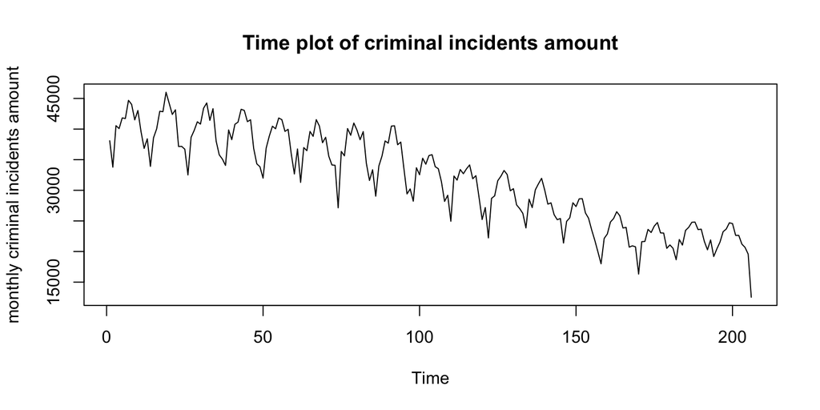

We can see an strong seasonal pattern for approx. every 12.5 months (50/4 = 12.5) as well as a decreasing trend. The variance seems stable here except little variation.

Then take a look of unsmoothed spectrum.

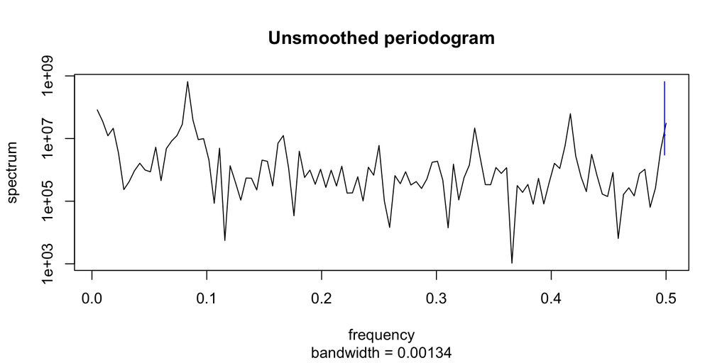

After smoothing, the spectrum is showed as following.

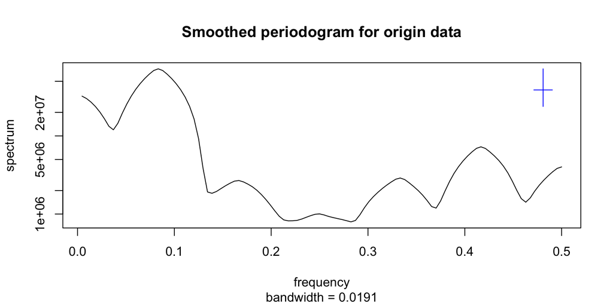

We can see there is a dominant freqency. After calculating, we get the dominant freqence is 0.0833. And the period is 12 month (1/0.0833), which is corresponding to the result derived from the time plot.

```
## The dominant frequence for origin data is 0.0833333333333333
```

```
## The dominant period for origin data is 12 month.
```

# 3.Detrending the Data

**Variance**

Although the variance showed in the time plot looks stable, I still take a look at the log data to see if there is any improvement of the stablility of variance.

Therefore, I plot the first degree differencing on original data and log data. The graph are shown below.

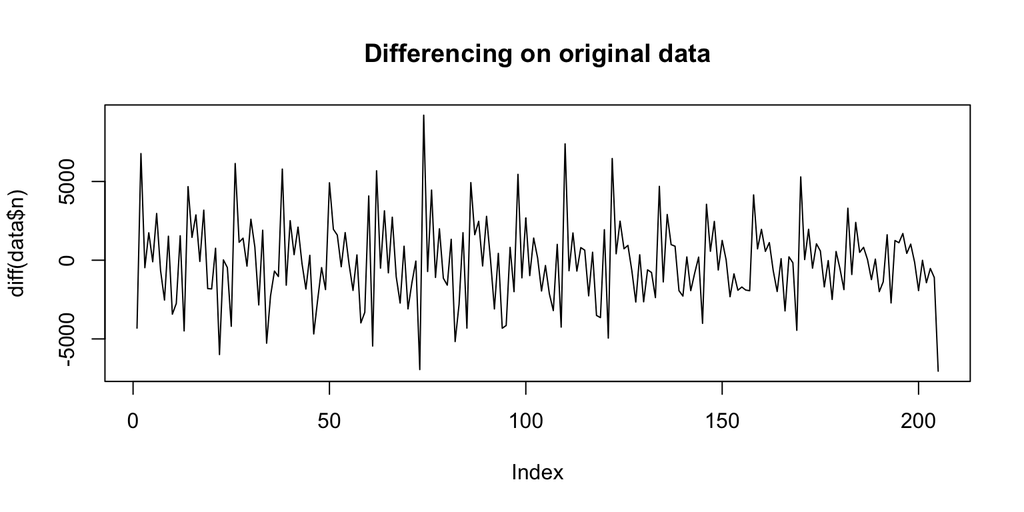

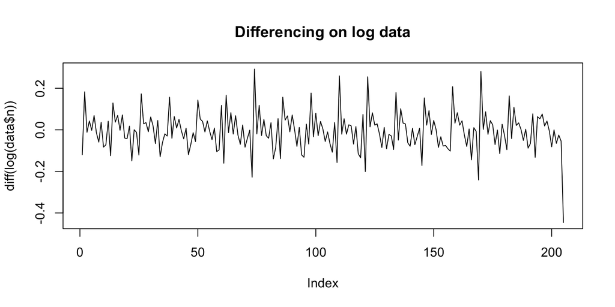

The fluctuate pattern showed in two graph is similar and both have an relative stable variance over time. Then take a look at the smoothed spectrum.

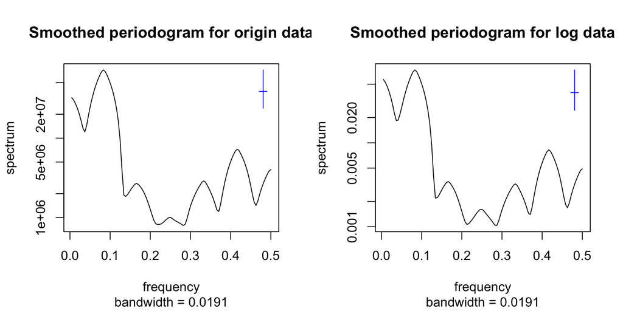

From the graph, we can see that the spectrum pattern of the origin data and log data are almost identical. Thus, combining the differencing graph, we can conclude that the log transformation doesn’t improve a lot and we will stick on the origin data.

**Trend**

As showing in the time plot, the origin data has a decreasing trend. To tackle with this trend, I apply the linear regression with ARMA errors technique.
For this dataset, we can see from the time plot, the decreasing trend is obvious from 2001 to 2016 while after 2016, the trend of the data becomes flat. Thus, I applied the model:
$$X = \beta_1 * \mathrm{Month Index} + \beta_2 * \mathrm{Month Index}^2 + \beta_3 * \mathrm{Month Index}^3 + \eta_n$$
Here, $X$ is the monthly amount of the criminal incidents and $\mathrm{Month Index}$ is calculated by transforming the year-month date to month, i.e. transform 2001-01 to 1 and 2018-02 to 206. $\eta_n$ is a correlated ARMA error which will be analyzed later. The following is the summary of the linear model.

```
##
## Call:
## lm(formula = data$n ~ month + I(month^2) + I(month^3))
##
## Residuals:
##     Min      1Q  Median      3Q     Max
## -9497.7 -1584.7   436.6  2180.7  6271.8
##
## Coefficients:
##               Estimate Std. Error t value Pr(>|t|)
## (Intercept)  3.948e+04  8.772e+02  45.006  < 2e-16 ***
## month        7.318e+01  3.661e+01   1.999    0.047 *
## I(month^2)  -1.908e+00  4.105e-01  -4.649 6.02e-06 ***
## I(month^3)   5.398e-03  1.304e-03   4.141 5.08e-05 ***
## ---
## Signif. codes:  0 '***' 0.001 '**' 0.01 '*' 0.05 '.' 0.1 ' ' 1
##
## Residual standard error: 3091 on 202 degrees of freedom
## Multiple R-squared:  0.8346, Adjusted R-squared:  0.8322
## F-statistic: 339.9 on 3 and 202 DF,  p-value: < 2.2e-16
```

We see that all the polynomial coefficients are being evaluated as significant. Also plot the data and the models.

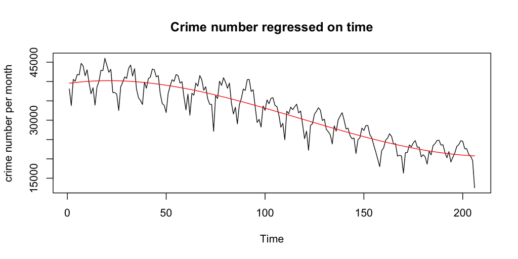

The model is ploted in red. By the plot, we can see that the model fits the trend of the data pretty well. Therefore, I will use this ploynoimial.

# 4.Seasonality Examination

Apart from the ploynoimial term in the linear regression with ARMA errors, we still need to determine the ARMA error term. First plot the ACF(here I use correlation plot) of the residuals of the linear model.

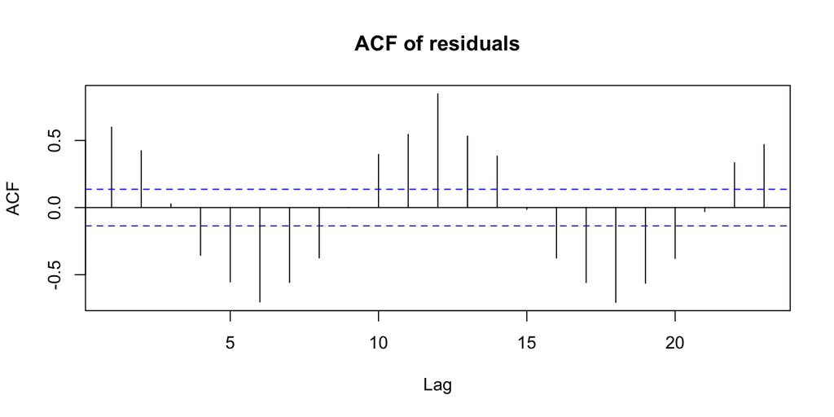

From the ACF plot, we can see a significant periodic existing in the residual of the linear model. I will add AR(2) to the model to fit the seasonal trend of the residual. Then, plot the smoothed spectrum of residuals.

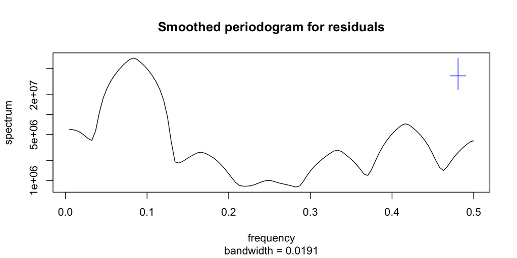

```
## The dominant frequence for residuals is 0.0833333333333333
```

```
## The dominant period for residuals is 12 month.
```

Based on the result of period showed above, residuals also follow the 12 month period as the origin data. Thus, it is proper to model the residual by monthly SARIMA model(period = 12).

# 5.Model Fitting

**Model for residuals**

Next step is to fit a SARIMA model to the residuals of the linear model. As the analysis result above, the fitted model will be a model whose period equals to 12 and goed with AR(2) for the annual polynomial. To determine the model for monthly part, we calculate the AIC.

AIC Values of ARIMA models for Model Errors with AR(2) Seasonal Component, period=12

|  | MA0 | MA1 | MA2 | MA3 | MA4 |
| --- | --- | --- | --- | --- | --- |
| **AR0** | 3569.297 | 3533.880 | 3525.50 | 3522.375 | 3522.673 |
| **AR1** | 3517.969 | 3515.704 | 3517.26 | 3519.023 | 3521.021 |

Among the table, SARIMA(1,0,1)x(2,0,0) with period equals to 12 has the lowest AIC and it’s a simple model. We will stick with this model for residuals.

Fit SARIMA(1,0,1)x(2,0,0) with period = 12 model to the residuals. The summary is showed below.

```
##
## Call:
## arima(x = lm1$residuals, order = c(1, 0, 1), seasonal = list(order = c(2, 0,
##     0), period = 12))
##
## Coefficients:
##          ar1      ma1    sar1    sar2  intercept
##       0.7410  -0.3167  0.5507  0.3668   200.8405
## s.e.  0.0993   0.1473  0.0697  0.0718  1509.3363
##
## sigma^2 estimated as 1301627:  log likelihood = -1752.85,  aic = 3515.7
```

Then look at the diagnostic for this fitting model on residuals. The error of this SARIMA model assumed to be a white noise. First check the ACF(here I use correlation plot) of the SARIMA model error.

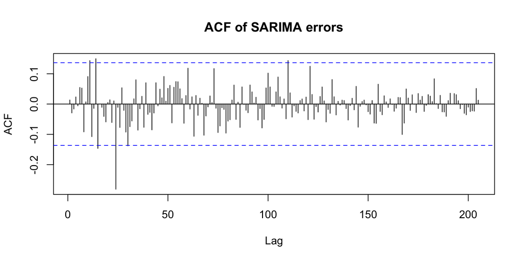

In plot, we see there are still 5 violations (out of 206 lags) of our hypothesis testing lines of IID errors in our model but the seasonallity is disappear. The 5 violations seems random, so here I didn’t take them into consideration. The errors are approx. uncorrelated.

Then plot the smoothed spectrum of the error.

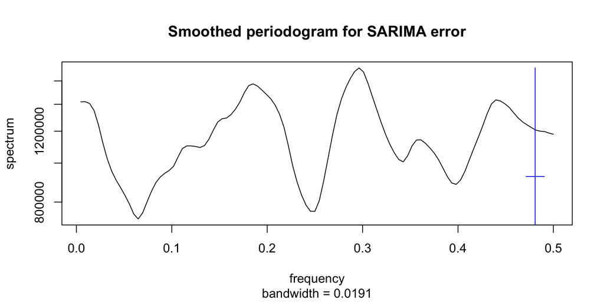

From the plot, we see dominant freqence is eliminated. There is no dominant cycles, which is also evidence of non-seasonal errors.

Then test the noemality of errors by drawing qq plot.

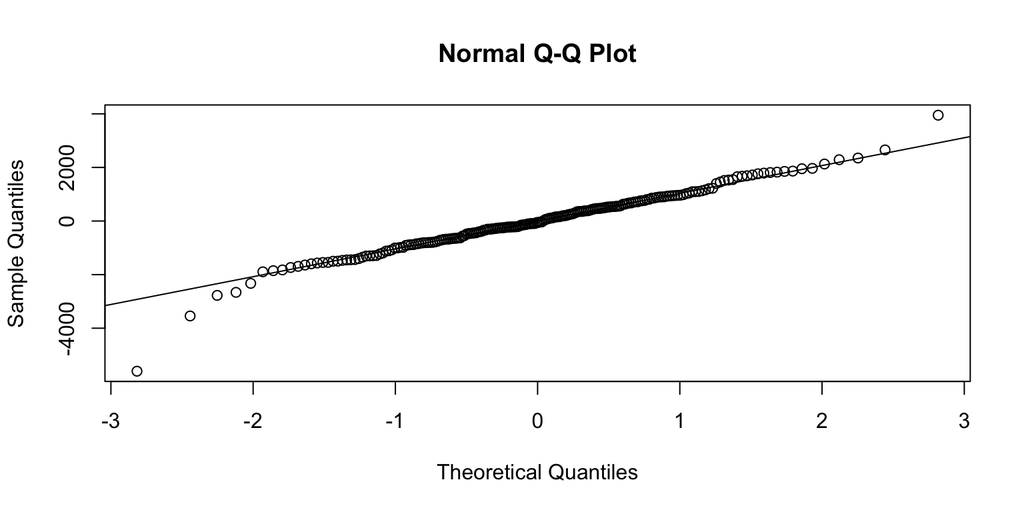

We see the result of qq plot is pretty well, indicating that the error follows normal distribution.